# Rmd_Example

MSCI 599

# Big heading

## Medium heading

### Small heading

#### Tiny heading

This is an example of an .Rmd file. We can define code chunks by using three grave accents, followed by curly brackets around r. A code chunk looks like this;

```r
x = c(1,2,3)
y = c(2,4,6)
```

If we write code that produces output, such as this:

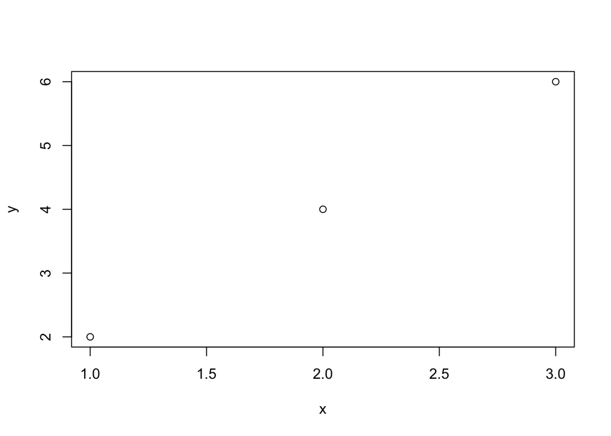

```r
plot(x,y)
```

The output will appear inline in the rendered document right after the code chunk. If you don’t want the code of a particular code chunk to appear in the final document, but still want to show the output (e.g. a plot), then you can include echo = FALSE in the code chunk instructions:

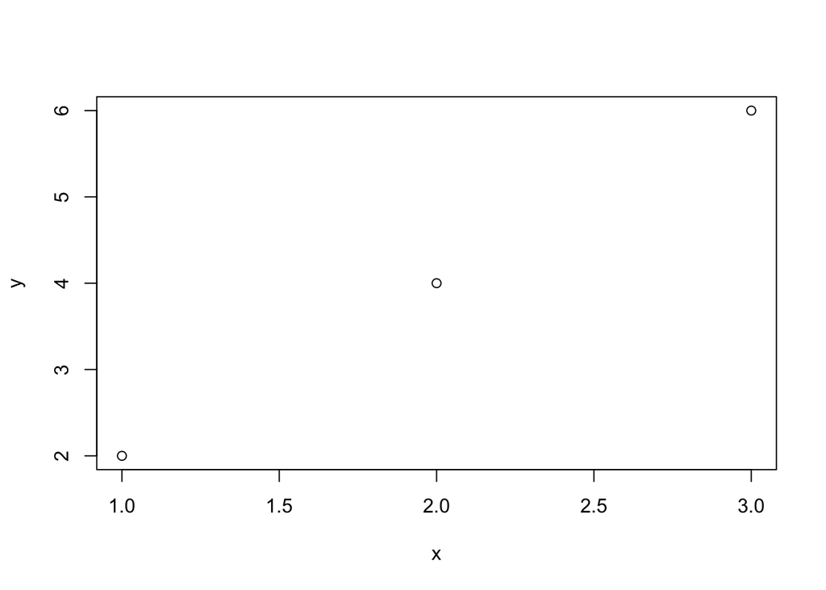

There are plenty of other code chunk instructions you can include in the curly braces to customize your `.Rmd` file.

Bulleted lists:

My family’s fave pizza toppings:

- pineapple
- bacon

My pet’s in order of how much mischievous they are:

1. Clyde (dog-cat)
2. Bonnie (cat)
3. Nana (dog-cat)

I can italicize text like *this* or like *this* and I can embolden text like **this** or like **this**

superscript<sup>23</sup> and subscript<sub>2</sub>